# Optimal Treatment Analysis

## Outcome Variable

**Outcome Variable:** ever_wasted

## Predictor Variables

**Intervention Variable:** fhtcm

**Adjustment Set:**

- arm
- W_mage
- W_fage
- meducyrs
- feducyrs
- W_mhtcm
- W_mwtkg
- W_mbmi
- single
- delta_W_mage
- delta_W_fage
- delta_meducyrs
- delta_feducyrs
- delta_W_mhtcm
- delta_W_mwtkg
- delta_W_mbmi
- delta_single

## Stratifying Variables

The analysis was stratified on these variable(s):

- agecat
- studyid
- country

## Data Summary

| agecat | studyid | country | fhtcm | ever_wasted | n_cell | n |
| --- | --- | --- | --- | --- | --- | --- |
| 0-24 months | ki1000304b-SAS-CompFeed | INDIA | >=167 cm | 0 | 73 | 243 |
| 0-24 months | ki1000304b-SAS-CompFeed | INDIA | >=167 cm | 1 | 37 | 243 |
| 0-24 months | ki1000304b-SAS-CompFeed | INDIA | <162 cm | 0 | 37 | 243 |
| 0-24 months | ki1000304b-SAS-CompFeed | INDIA | <162 cm | 1 | 23 | 243 |
| 0-24 months | ki1000304b-SAS-CompFeed | INDIA | [162-167) cm | 0 | 44 | 243 |
| 0-24 months | ki1000304b-SAS-CompFeed | INDIA | [162-167) cm | 1 | 29 | 243 |
| 0-24 months | ki1000304b-SAS-FoodSuppl | INDIA | >=167 cm | 0 | 9 | 101 |
| 0-24 months | ki1000304b-SAS-FoodSuppl | INDIA | >=167 cm | 1 | 12 | 101 |
| 0-24 months | ki1000304b-SAS-FoodSuppl | INDIA | <162 cm | 0 | 18 | 101 |
| 0-24 months | ki1000304b-SAS-FoodSuppl | INDIA | <162 cm | 1 | 20 | 101 |
| 0-24 months | ki1000304b-SAS-FoodSuppl | INDIA | [162-167) cm | 0 | 23 | 101 |
| 0-24 months | ki1000304b-SAS-FoodSuppl | INDIA | [162-167) cm | 1 | 19 | 101 |
| 0-24 months | ki1101329-Keneba | GAMBIA | >=167 cm | 0 | 758 | 1933 |
| 0-24 months | ki1101329-Keneba | GAMBIA | >=167 cm | 1 | 490 | 1933 |
| 0-24 months | ki1101329-Keneba | GAMBIA | <162 cm | 0 | 80 | 1933 |
| 0-24 months | ki1101329-Keneba | GAMBIA | <162 cm | 1 | 52 | 1933 |
| 0-24 months | ki1101329-Keneba | GAMBIA | [162-167) cm | 0 | 324 | 1933 |
| 0-24 months | ki1101329-Keneba | GAMBIA | [162-167) cm | 1 | 229 | 1933 |
| 0-24 months | ki1119695-PROBIT | BELARUS | >=167 cm | 0 | 4155 | 6249 |
| 0-24 months | ki1119695-PROBIT | BELARUS | >=167 cm | 1 | 1681 | 6249 |
| 0-24 months | ki1119695-PROBIT | BELARUS | <162 cm | 0 | 56 | 6249 |
| 0-24 months | ki1119695-PROBIT | BELARUS | <162 cm | 1 | 27 | 6249 |
| 0-24 months | ki1119695-PROBIT | BELARUS | [162-167) cm | 0 | 241 | 6249 |
| 0-24 months | ki1119695-PROBIT | BELARUS | [162-167) cm | 1 | 89 | 6249 |
| 0-24 months | ki1135781-COHORTS | GUATEMALA | >=167 cm | 0 | 22 | 227 |
| 0-24 months | ki1135781-COHORTS | GUATEMALA | >=167 cm | 1 | 6 | 227 |
| 0-24 months | ki1135781-COHORTS | GUATEMALA | <162 cm | 0 | 78 | 227 |
| 0-24 months | ki1135781-COHORTS | GUATEMALA | <162 cm | 1 | 44 | 227 |
| 0-24 months | ki1135781-COHORTS | GUATEMALA | [162-167) cm | 0 | 55 | 227 |
| 0-24 months | ki1135781-COHORTS | GUATEMALA | [162-167) cm | 1 | 22 | 227 |

[output cut: 60 more lines]

The following strata were considered:

- agecat: 0-24 months, studyid: ki1000304b-SAS-CompFeed, country: INDIA
- agecat: 0-24 months, studyid: ki1000304b-SAS-FoodSuppl, country: INDIA
- agecat: 0-24 months, studyid: ki1101329-Keneba, country: GAMBIA
- agecat: 0-24 months, studyid: ki1119695-PROBIT, country: BELARUS
- agecat: 0-24 months, studyid: ki1135781-COHORTS, country: GUATEMALA
- agecat: 0-6 months, studyid: ki1000304b-SAS-CompFeed, country: INDIA
- agecat: 0-6 months, studyid: ki1000304b-SAS-FoodSuppl, country: INDIA
- agecat: 0-6 months, studyid: ki1101329-Keneba, country: GAMBIA
- agecat: 0-6 months, studyid: ki1119695-PROBIT, country: BELARUS
- agecat: 0-6 months, studyid: ki1135781-COHORTS, country: GUATEMALA
- agecat: 6-24 months, studyid: ki1000304b-SAS-CompFeed, country: INDIA
- agecat: 6-24 months, studyid: ki1000304b-SAS-FoodSuppl, country: INDIA
- agecat: 6-24 months, studyid: ki1101329-Keneba, country: GAMBIA
- agecat: 6-24 months, studyid: ki1119695-PROBIT, country: BELARUS
- agecat: 6-24 months, studyid: ki1135781-COHORTS, country: GUATEMALA

### Dropped Strata

Some strata were dropped due to rare outcomes:

- agecat: 0-6 months, studyid: ki1000304b-SAS-FoodSuppl, country: INDIA
- agecat: 0-6 months, studyid: ki1135781-COHORTS, country: GUATEMALA
- agecat: 6-24 months, studyid: ki1119695-PROBIT, country: BELARUS
- agecat: 6-24 months, studyid: ki1135781-COHORTS, country: GUATEMALA

## Methods Detail

We’re interested in the causal parameters $E[Y_a]$ for all values of $a \in \mathcal{A}$. These parameters represent the mean outcome if, possibly contrary to fact, we intervened to set all units to have $A=a$. Under the randomization and positivity assumptions, these are identified by the statistical parameters $\psi_a=E_W[E_{Y|A,W}(Y|A=a,W)]$. In addition, we’re interested in the mean of $Y$, $E[Y]$ under no intervention (the observed mean). We will estimate these parameters by using SuperLearner to fit the relevant likelihood factors – $E_{Y|A,W}(Y|A=a,W)$ and $p(A=a|W)$, and then updating our likelihood fit using a joint TMLE.

For unadjusted analyses ($W=\{\}$), initial likelihoods were estimated using Lrnr_glm to estimate the simple $E(Y|A)$ and Lrnr_mean to estimate $p(A)$. For adjusted analyses, a small library containing Lrnr_glmnet, Lrnr_xgboost, and Lrnr_mean was used.

Having estimated these parameters, we will then use the delta method to estimate relative risks and attributable risks relative to a prespecified baseline level of $A$.

# Results Detail

## Results Plots

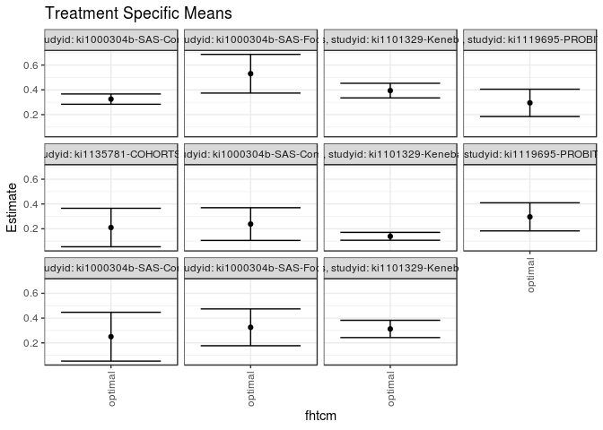

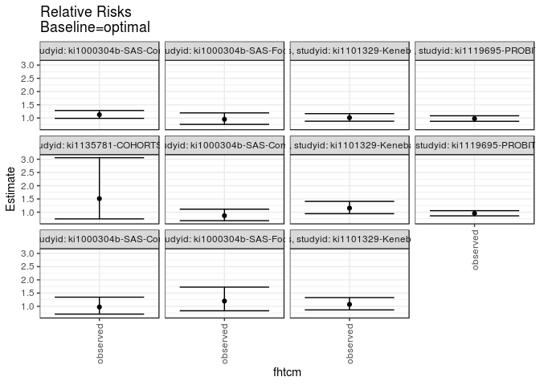

## Results Table

### Parameter: TSM

| agecat | studyid | country | intervention_level | baseline_level | estimate | ci_lower | ci_upper |
| --- | --- | --- | --- | --- | --- | --- | --- |
| 0-24 months | ki1000304b-SAS-CompFeed | INDIA | optimal | NA | 0.3253051 | 0.2839487 | 0.3666616 |
| 0-24 months | ki1000304b-SAS-FoodSuppl | INDIA | optimal | NA | 0.5303354 | 0.3741623 | 0.6865085 |
| 0-24 months | ki1101329-Keneba | GAMBIA | optimal | NA | 0.3940263 | 0.3348916 | 0.4531610 |
| 0-24 months | ki1119695-PROBIT | BELARUS | optimal | NA | 0.2950827 | 0.1847880 | 0.4053775 |
| 0-24 months | ki1135781-COHORTS | GUATEMALA | optimal | NA | 0.2099261 | 0.0545609 | 0.3652913 |
| 0-6 months | ki1000304b-SAS-CompFeed | INDIA | optimal | NA | 0.2378681 | 0.1059047 | 0.3698314 |
| 0-6 months | ki1101329-Keneba | GAMBIA | optimal | NA | 0.1389226 | 0.1071836 | 0.1706617 |
| 0-6 months | ki1119695-PROBIT | BELARUS | optimal | NA | 0.2959564 | 0.1824358 | 0.4094771 |
| 6-24 months | ki1000304b-SAS-CompFeed | INDIA | optimal | NA | 0.2499005 | 0.0528748 | 0.4469262 |
| 6-24 months | ki1000304b-SAS-FoodSuppl | INDIA | optimal | NA | 0.3255521 | 0.1768767 | 0.4742275 |
| 6-24 months | ki1101329-Keneba | GAMBIA | optimal | NA | 0.3123701 | 0.2425216 | 0.3822186 |

### Parameter: E(Y)

| agecat | studyid | country | intervention_level | baseline_level | estimate | ci_lower | ci_upper |
| --- | --- | --- | --- | --- | --- | --- | --- |
| 0-24 months | ki1000304b-SAS-CompFeed | INDIA | observed | NA | 0.3662551 | 0.2722088 | 0.4603015 |
| 0-24 months | ki1000304b-SAS-FoodSuppl | INDIA | observed | NA | 0.5049505 | 0.4069571 | 0.6029439 |
| 0-24 months | ki1101329-Keneba | GAMBIA | observed | NA | 0.3988619 | 0.3770274 | 0.4206964 |
| 0-24 months | ki1119695-PROBIT | BELARUS | observed | NA | 0.2875660 | 0.1862253 | 0.3889068 |
| 0-24 months | ki1135781-COHORTS | GUATEMALA | observed | NA | 0.3171806 | 0.2565070 | 0.3778543 |
| 0-6 months | ki1000304b-SAS-CompFeed | INDIA | observed | NA | 0.2066116 | 0.1377408 | 0.2754823 |
| 0-6 months | ki1101329-Keneba | GAMBIA | observed | NA | 0.1601173 | 0.1427056 | 0.1775290 |
| 0-6 months | ki1119695-PROBIT | BELARUS | observed | NA | 0.2824452 | 0.1805355 | 0.3843549 |
| 6-24 months | ki1000304b-SAS-CompFeed | INDIA | observed | NA | 0.2434783 | 0.1268958 | 0.3600607 |
| 6-24 months | ki1000304b-SAS-FoodSuppl | INDIA | observed | NA | 0.3900000 | 0.2939212 | 0.4860788 |
| 6-24 months | ki1101329-Keneba | GAMBIA | observed | NA | 0.3349541 | 0.3134470 | 0.3564611 |

### Parameter: RR

| agecat | studyid | country | intervention_level | baseline_level | estimate | ci_lower | ci_upper |
| --- | --- | --- | --- | --- | --- | --- | --- |
| 0-24 months | ki1000304b-SAS-CompFeed | INDIA | observed | optimal | 1.1258818 | 0.9869746 | 1.284339 |
| 0-24 months | ki1000304b-SAS-FoodSuppl | INDIA | observed | optimal | 0.9521342 | 0.7600086 | 1.192828 |
| 0-24 months | ki1101329-Keneba | GAMBIA | observed | optimal | 1.0122721 | 0.8796502 | 1.164889 |
| 0-24 months | ki1119695-PROBIT | BELARUS | observed | optimal | 0.9745267 | 0.8756905 | 1.084518 |
| 0-24 months | ki1135781-COHORTS | GUATEMALA | observed | optimal | 1.5109153 | 0.7465808 | 3.057760 |
| 0-6 months | ki1000304b-SAS-CompFeed | INDIA | observed | optimal | 0.8685973 | 0.6779217 | 1.112903 |
| 0-6 months | ki1101329-Keneba | GAMBIA | observed | optimal | 1.1525646 | 0.9434595 | 1.408015 |
| 0-6 months | ki1119695-PROBIT | BELARUS | observed | optimal | 0.9543471 | 0.8612679 | 1.057486 |
| 6-24 months | ki1000304b-SAS-CompFeed | INDIA | observed | optimal | 0.9743009 | 0.7055006 | 1.345516 |
| 6-24 months | ki1000304b-SAS-FoodSuppl | INDIA | observed | optimal | 1.1979649 | 0.8319041 | 1.725102 |
| 6-24 months | ki1101329-Keneba | GAMBIA | observed | optimal | 1.0722988 | 0.8646503 | 1.329815 |

### Parameter: PAR

| agecat | studyid | country | intervention_level | baseline_level | estimate | ci_lower | ci_upper |
| --- | --- | --- | --- | --- | --- | --- | --- |
| 0-24 months | ki1000304b-SAS-CompFeed | INDIA | optimal | NA | 0.0409500 | -0.0123365 | 0.0942365 |
| 0-24 months | ki1000304b-SAS-FoodSuppl | INDIA | optimal | NA | -0.0253849 | -0.1449136 | 0.0941437 |
| 0-24 months | ki1101329-Keneba | GAMBIA | optimal | NA | 0.0048355 | -0.0505009 | 0.0601720 |
| 0-24 months | ki1119695-PROBIT | BELARUS | optimal | NA | -0.0075167 | -0.0393262 | 0.0242928 |
| 0-24 months | ki1135781-COHORTS | GUATEMALA | optimal | NA | 0.1072545 | -0.0410804 | 0.2555894 |
| 0-6 months | ki1000304b-SAS-CompFeed | INDIA | optimal | NA | -0.0312565 | -0.0990040 | 0.0364910 |
| 0-6 months | ki1101329-Keneba | GAMBIA | optimal | NA | 0.0211947 | -0.0066962 | 0.0490856 |
| 0-6 months | ki1119695-PROBIT | BELARUS | optimal | NA | -0.0135113 | -0.0446855 | 0.0176630 |
| 6-24 months | ki1000304b-SAS-CompFeed | INDIA | optimal | NA | -0.0064222 | -0.0899667 | 0.0771223 |
| 6-24 months | ki1000304b-SAS-FoodSuppl | INDIA | optimal | NA | 0.0644479 | -0.0540141 | 0.1829098 |
| 6-24 months | ki1101329-Keneba | GAMBIA | optimal | NA | 0.0225840 | -0.0446881 | 0.0898561 |

### Parameter: PAF

| agecat | studyid | country | intervention_level | baseline_level | estimate | ci_lower | ci_upper |
| --- | --- | --- | --- | --- | --- | --- | --- |
| 0-24 months | ki1000304b-SAS-CompFeed | INDIA | optimal | NA | 0.1118073 | -0.0131974 | 0.2213893 |
| 0-24 months | ki1000304b-SAS-FoodSuppl | INDIA | optimal | NA | -0.0502721 | -0.3157746 | 0.1616562 |
| 0-24 months | ki1101329-Keneba | GAMBIA | optimal | NA | 0.0121233 | -0.1368155 | 0.1415491 |
| 0-24 months | ki1119695-PROBIT | BELARUS | optimal | NA | -0.0261391 | -0.1419560 | 0.0779316 |
| 0-24 months | ki1135781-COHORTS | GUATEMALA | optimal | NA | 0.3381495 | -0.3394398 | 0.6729632 |
| 0-6 months | ki1000304b-SAS-CompFeed | INDIA | optimal | NA | -0.1512815 | -0.4750967 | 0.1014493 |
| 0-6 months | ki1101329-Keneba | GAMBIA | optimal | NA | 0.1323697 | -0.0599289 | 0.2897803 |
| 0-6 months | ki1119695-PROBIT | BELARUS | optimal | NA | -0.0478367 | -0.1610789 | 0.0543607 |
| 6-24 months | ki1000304b-SAS-CompFeed | INDIA | optimal | NA | -0.0263770 | -0.4174333 | 0.2567907 |
| 6-24 months | ki1000304b-SAS-FoodSuppl | INDIA | optimal | NA | 0.1652510 | -0.2020617 | 0.4203243 |
| 6-24 months | ki1101329-Keneba | GAMBIA | optimal | NA | 0.0674241 | -0.1565370 | 0.2480156 |